# Cochrane Dataset

`r`r PATH_HOME = path.expand(~) # user home PATH = file.path(PATH_HOME, ‘thesis/cochrane’)

# Read data

```r
source(file.path(PATH, 'prepare.R'))
yodata
```

[output not shown]

[output cut: 437 more lines]

`r`r # load(file = .RData) require(tidyverse) require(meta)

### Example Reviews

Anti-D administration in pregnancy for preventing Rhesus alloimmunisation: 2 Trials, 3 Identical outcome measures, but with different subgroups.

`r`r # arrange(filter(madata, file.nr==10) %>% select(comparison.name, outcome.name, outcome.measure, subgroup.name, study.name), study.name)

`r`r # arrange(filter(madata, file.nr==21) %>% select(comparison.name, outcome.name, outcome.measure, subgroup.name, study.name), study.name)

### Frequencies of Trials in the Reviews

Frequencies of trials analyzing the same subject in a review (with the same outcome measure):

`r`r madata %>% group_by(file.nr, outcome.nr, comparison.nr) %>% count %>% group_by(n) %>% count %>% filter(n < 15) %>% full_join( madata %>% group_by(file.nr, outcome.nr, comparison.nr) %>% count %>% group_by(n) %>% count %>% filter(n > 14) %>% ungroup %>% summarise(n = 15, nn = sum(nn))) %>%  
ggplot(aes(x = n, y = nn)) + geom_col(col = 15, fill = ) + theme_bw() + labs(title = Comparing the Same Subject per Review) + ylab()

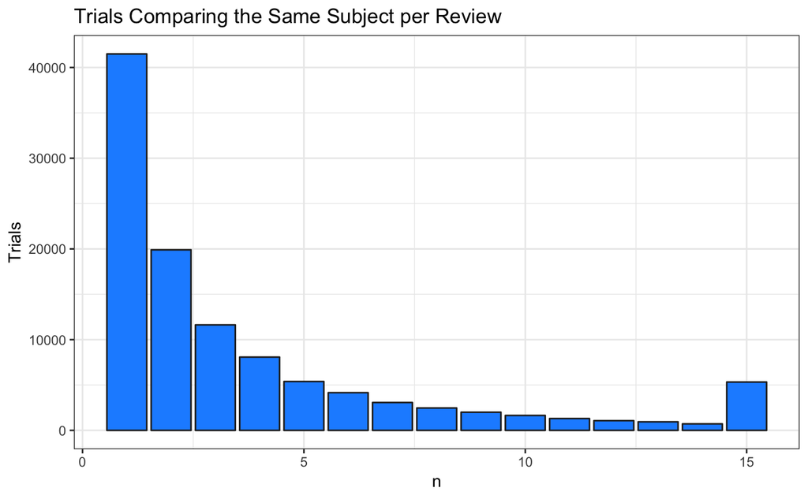

Frequencies of trials analyzing the same subject with the same subgroups in a review (and the same outcome measure):

`r`r madata %>% group_by(file.nr, outcome.nr, comparison.nr, subgroup.nr) %>% count %>% group_by(n) %>% count %>% filter(n < 15) %>% full_join( madata %>% group_by(file.nr, outcome.nr, comparison.nr, subgroup.nr) %>% count %>% group_by(n) %>% count %>% filter(n > 14) %>% ungroup %>% summarise(n = 15, nn = sum(nn))) %>%  
ggplot(aes(x = n, y = nn)) + geom_col(col = 15, fill = ) + theme_bw() + labs(title = Comparing the Same Subject in the Same Subgroups per Review) + ylab ()

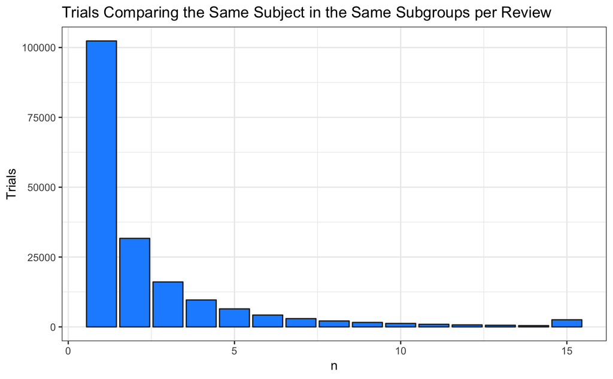

### Frequencies of Different Outcome Subjects per Review

`r`r # madata %>% group_by(file.nr) %>% summarise(diff.out = length(unique(outcome.name))) %>% count(diff.out) %>%  
# ggplot(aes(x = diff.out, y = n)) + geom_col(col = 15, fill = ) + # theme_bw() + labs(title = subjects per Review) + xlab(subjects per review)

### Analysis Study Year Frequencies

`r`r madata %>% filter(study.year > 1900 & study.year < 2019) %>% ggplot(aes(x = study.year)) + geom_histogram(col = 15, fill = ) + theme_bw() + labs(title = years of analyses)

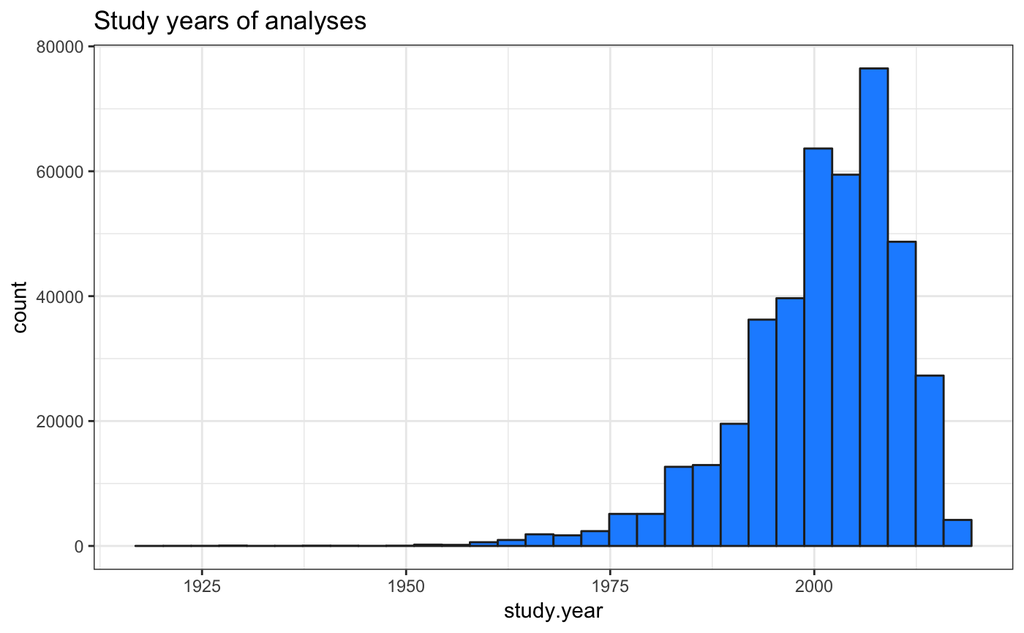

### Effect sizes over time

Odds ratios with initial finding > 1:

`r`r madata %>% filter(outcome.measure == Ratio) %>% filter(!is.na(study.year)) %>% group_by(file.nr, comparison.nr, subgroup.nr) %>% mutate(counts = n()) %>% filter(counts > 1) %>% mutate(first.effect = effect[which.min(study.year)]) %>% filter(first.effect > 1) %>% mutate(scaled.effect = scale(effect), scaled.time = scale(study.year)) %>% ggplot(aes(x = scaled.time, y = scaled.effect)) + geom_point(size = .5, alpha = 0.2) + geom_smooth(method = lm) + theme_bw() + labs(title = and centered OR over time, subtitle = finding > 1) + ylab(Ratio) + ylab()

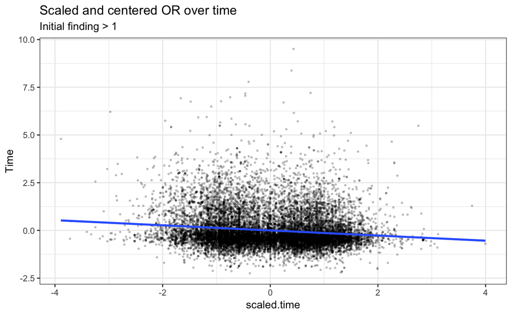

Odds ratios with initial finding < 1:

`r`r madata %>% filter(outcome.measure == Ratio) %>% filter(!is.na(study.year)) %>% group_by(file.nr, comparison.nr, subgroup.nr) %>% mutate(counts = n()) %>% filter(counts > 1) %>% mutate(first.effect = effect[which.min(study.year)]) %>% filter(first.effect < 1) %>% mutate(scaled.effect = scale(effect), scaled.time = scale(study.year)) %>% ggplot(aes(x = scaled.time, y = scaled.effect)) + geom_point(size = .35, alpha = 0.1) + geom_smooth(method = lm) + theme_bw() + labs(title = and centered OR over time, subtitle = finding < 1) + ylab(Ratio) + ylab()

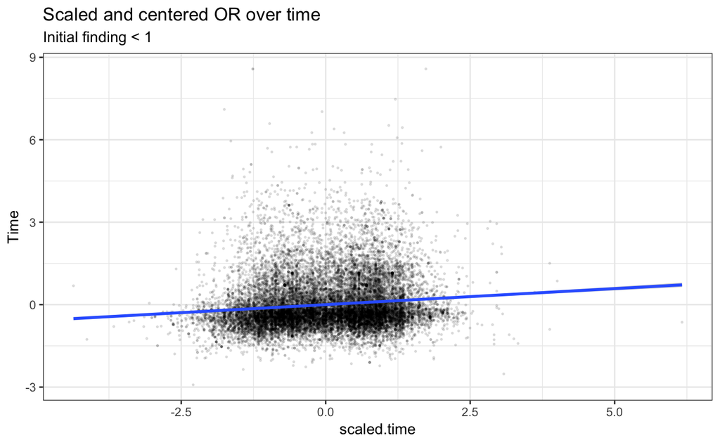

Risk ratios with initial finding > 1:

`r`r #Scaled RR over time with initial RR > 1 madata %>% filter(outcome.measure == Ratio) %>% filter(!is.na(study.year)) %>% group_by(file.nr, comparison.nr, subgroup.nr) %>% mutate(counts = n()) %>% filter(counts > 1) %>% mutate(first.effect = effect[which.min(study.year)]) %>% filter(first.effect > 1) %>% mutate(scaled.effect = scale(effect), scaled.time = scale(study.year)) %>% ggplot(aes(x = scaled.time, y = scaled.effect)) + geom_point(size = .25, alpha = 0.025) + geom_smooth(method = lm) + theme_bw() + labs(title = and centered RR over time, subtitle = finding > 1) + ylab(Ratio) + ylab() + xlim(c(-4,4)) + ylim(c(-5,7))

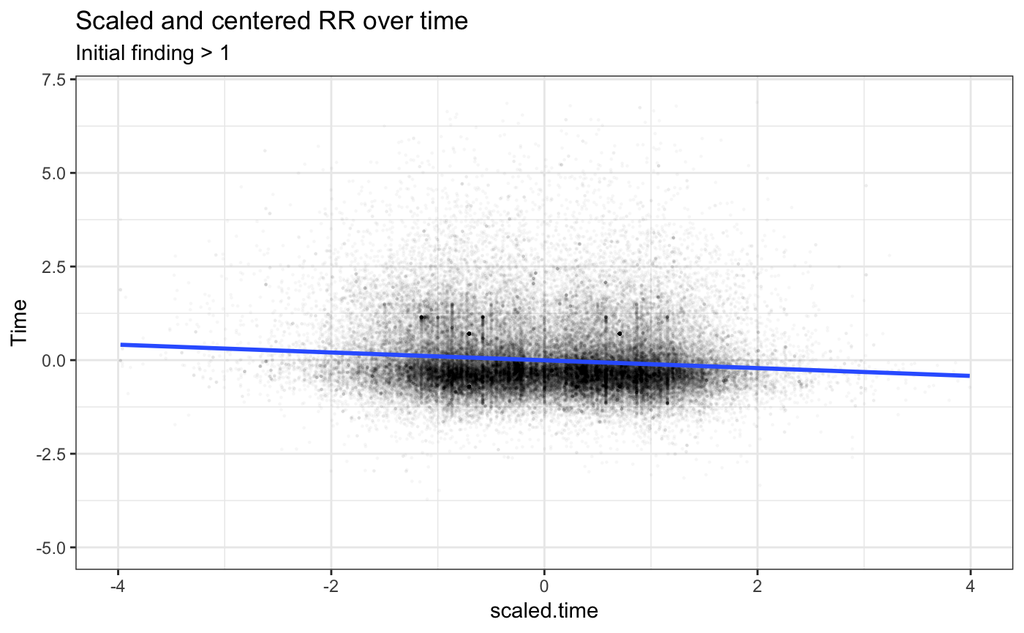

Risk ratios with initial finding < 1:

`r`r #Scaled RR over time with initial RR > 1 madata %>% filter(outcome.measure == Ratio) %>% filter(!is.na(study.year)) %>% group_by(file.nr, comparison.nr, subgroup.nr) %>% mutate(counts = n()) %>% filter(counts > 1) %>% mutate(first.effect = effect[which.min(study.year)]) %>% filter(first.effect < 1) %>% mutate(scaled.effect = scale(effect), scaled.time = scale(study.year)) %>% ggplot(aes(x = scaled.time, y = scaled.effect)) + geom_point(size = .2, alpha = 0.025) + geom_smooth(method = lm) + theme_bw() + labs(title = and centered RR over time, subtitle = finding < 1) + ylab(Ratio) + ylab() + xlim(c(-5,5)) + ylim(c(-5, 10))

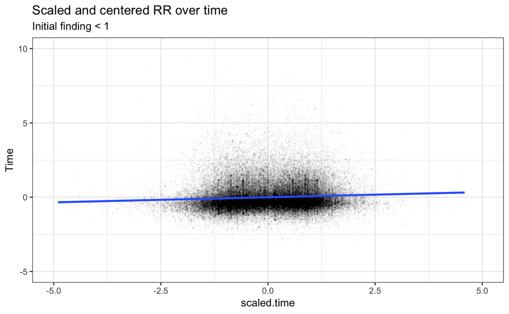

Statistical test to see if incorporation of a time - intial RR estimate improves a linear model for RR and time:

`r`r regression.temp <- madata %>% filter(outcome.measure == Ratio) %>% filter(!is.na(study.year)) %>% group_by(file.nr, comparison.nr, subgroup.nr) %>% mutate(counts = n()) %>% filter(counts > 1) %>% mutate(first.effect = effect[which.min(study.year)]) %>% mutate(effect.sign = ifelse(first.effect > 1, , ), scaled.effect = scale(effect), scaled.time = scale(study.year)) regression.temp$effect.sign <- as.factor(regression.temp$effect.sign) m1 <- lm(scaled.effect ~ scaled.time, data = regression.temp) m2 <- lm(scaled.effect ~ scaled.time + effect.sign, data = regression.temp) m3 <- lm(scaled.effect ~ scaled.time * effect.sign, data = regression.temp) anova(m1, m2, m3)

```
Analysis of Variance Table

Model 1: scaled.effect ~ scaled.time
Model 2: scaled.effect ~ scaled.time + effect.sign
Model 3: scaled.effect ~ scaled.time * effect.sign
  Res.Df    RSS Df Sum of Sq      F Pr(>F)
1 197886 182584
2 197885 182584  1       0.0    0.0      1
3 197884 181306  1    1277.8 1394.7 <2e-16 ***
---
Signif. codes:  0 '***' 0.001 '**' 0.01 '*' 0.05 '.' 0.1 ' ' 1
```

### Cochrane Heterogeneity test

Cochrane heterogeneity test for Odds Ratios (with meta::metabin()):

`r`r madata %>% group_by(file.nr, outcome.nr, comparison.nr, subgroup.nr) %>% filter(outcome.measure == Ratio) %>% mutate(counts = n()) %>% filter(counts > 1) %>% filter(events1 > 0 & events2 > 0) %>% summarise( Q = metabin(event.e = events1, n.e = total1, event.c = events2, n.c = total2, studlab = study.name, method = , sm = )$Q, p.value = metabin(event.e = events1, n.e = total1, event.c = events2, n.c = total2, studlab = study.name, method = \Inverse\, sm = \OR\)$pval.Q) %>% ggplot(aes(x = p.value)) + geom_histogram(col = 15, fill = ) + theme_bw() + labs(title = Heterogeneity Test P-values of ORs)

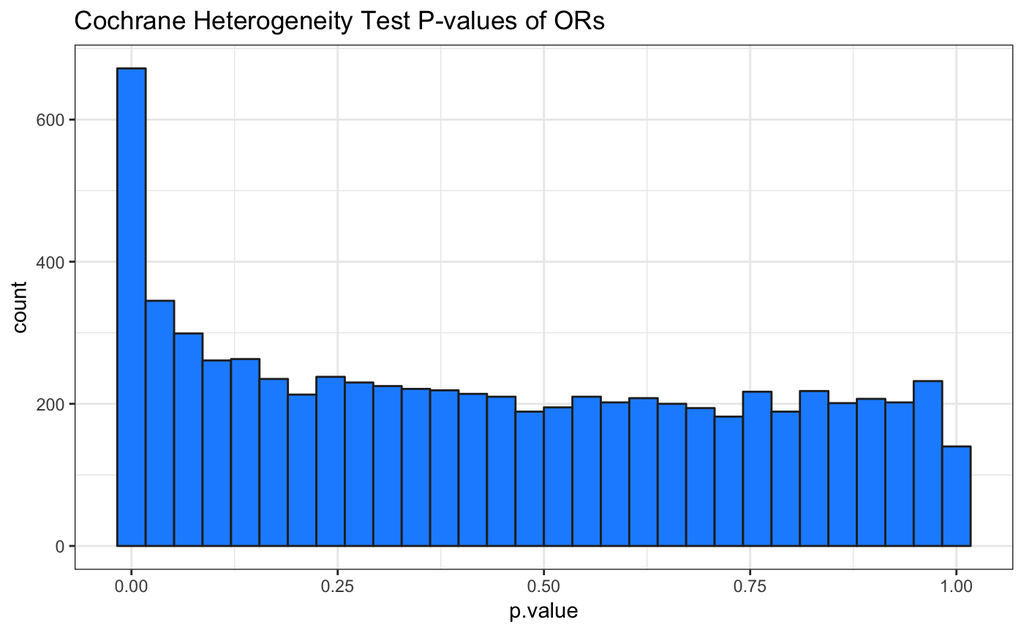

## Transformation to fishers z-scaled correlation

Mean differences and binary outcomes can be compared by transformation to standardized mean difference to correlation and finally to fishers z-scaled correlation.

`r`r #Transform Binary outcomes to odds ratios -> standardized mean difference -> correlation -> fisher scala correlation madata <- madata %>% filter(!is.na(outcome.measure)) %>% mutate(odds.ratio = (events1/(total1 - events1)) / (events2/(total2 - events2))) %>% mutate(std.mean.d = log(odds.ratio) * (sqrt(3)/pi)) %>% mutate(correlation = std.mean.d/sqrt((std.mean.d^2) + ((total1 + total2)^2)/(total2*total1))) %>% mutate(fishersz = 0.5* log( (1 + correlation)/(1 - correlation) ), variance = 1/(total1 + total2 - 3))

```
NAs produced by integer overflow
```

`r`r #Transform mean difference to standardized mean difference -> correlation -> fisher scala correlation madata[madata$outcome.measure == Difference, ] <- madata %>% filter(outcome.measure == Difference) %>% mutate(std.mean.d = effect/se) %>% mutate(correlation = std.mean.d/sqrt(std.mean.d^2 + ((total1 + total2)^2)/(total2*total1))) %>% mutate(fishersz = 0.5* log( (1 + correlation)/(1 - correlation) ), variance = 1/(total1 + total2 - 3))

```
NAs produced by integer overflow
```

`r`r madata[madata$outcome.measure == . Mean Difference, ] <- madata %>% filter(outcome.measure == . Mean Difference) %>% mutate(std.mean.d = effect) %>% mutate(correlation = std.mean.d/sqrt(std.mean.d^2 + ((total1 + total2)^2)/(total2*total1))) %>% mutate(fishersz = 0.5* log( (1 + correlation)/(1 - correlation) ), variance = 1/(total1 + total2 - 3))

```
NAs produced by integer overflow
```

`r`r madata[madata$outcome.measure == difference, ] <- madata %>% filter(outcome.measure == difference) %>% mutate(std.mean.d = effect) %>% mutate(correlation = std.mean.d/sqrt(std.mean.d^2 + ((total1 + total2)^2)/(total2*total1))) %>% mutate(fishersz = 0.5* log( (1 + correlation)/(1 - correlation) ), variance = 1/(total1 + total2 - 3)) madata[madata$outcome.measure == difference, ] <- madata %>% filter(outcome.measure == difference) %>% mutate(std.mean.d = effect) %>% mutate(correlation = std.mean.d/sqrt(std.mean.d^2 + ((total1 + total2)^2)/(total2*total1))) %>% mutate(fishersz = 0.5* log( (1 + correlation)/(1 - correlation) ), variance = 1/(total1 + total2 - 3))

[figure not shown]

[figure not shown]